# STAT 240 Discussion 9

## Group 319C

## **LILY FRANKS**, HAOXUAN LU, SHRUTHI SRINIVASAN, MICHAEL HANDLER

## Regression

The simple linear regression model is that a response variable $y$ can be explained with a linear model for a variable $x$ plus random error. The equation
$$\mathsf{E}(y) = a_1 + a_2 x$$
describes a linear relationship between the expected value of $y$ and a variable $x$. The model is more completely specified by adding a random model for how the individual observations of the response variable vary from their expected values.
$$y_i = a_1 + a_2 x_i + \varepsilon_i$$
where
$$\varepsilon_i \sim \text{Normal}(0,\sigma)$$
where $\sigma$ is the standard deviation.

## Data

The following code reads in the Madison weather data and calculates the average winter temperature (November through February) for each year and graphs the data and a fitted linear model.

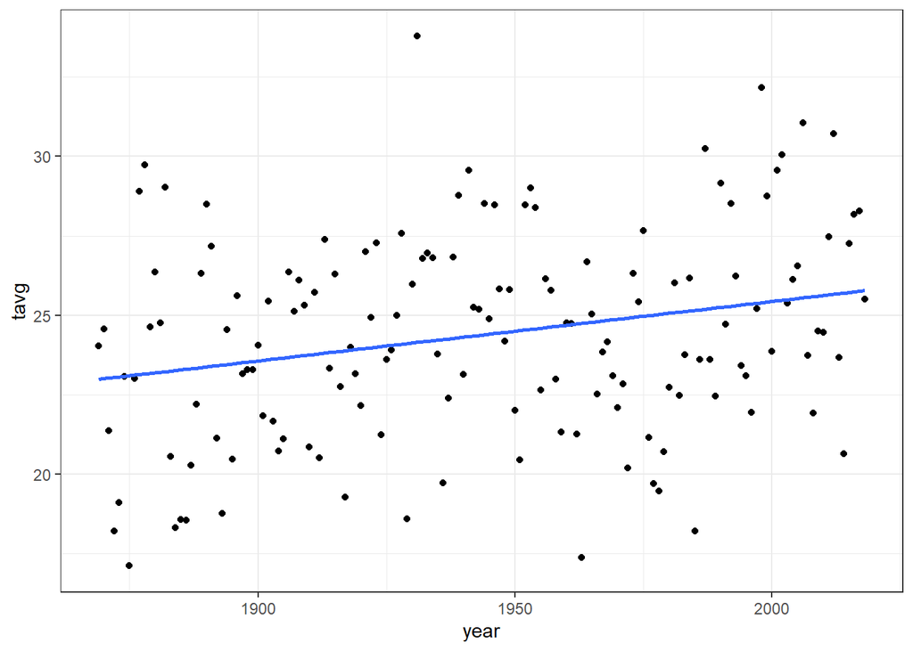

```r
## Read and transform the Madison weather data
mw <- read_csv("../../data/madison-weather-2020-clean.csv")

mw_winter <- mw %>%
  filter(month=="Nov" | month=="Dec" | month=="Jan" | month=="Feb") %>%
  group_by(year) %>%
  summarize(tavg = mean(tavg))

ggplot(mw_winter, aes(x=year,y=tavg)) +
  geom_point() +
  geom_smooth(method="lm", se=FALSE) +
  theme_bw()
```

## Regression Model

The next block of code fits a linear model to the data and uses functions `add_predictions()` and `add_residuals()` from the tidyverse package `modelr` to add columns `pred` and `resid` which contain predicted values and residuals, respectively.

```r
fit <- lm(tavg ~ year, data=mw_winter)
summary(fit)
```

```
##
## Call:
## lm(formula = tavg ~ year, data = mw_winter)
##
## Residuals:
##     Min      1Q  Median      3Q     Max
## -7.3681 -2.2764 -0.1055  2.3163  9.6307
##
## Coefficients:
##               Estimate Std. Error t value Pr(>|t|)
## (Intercept) -11.983193  11.604048  -1.033  0.30344
## year          0.018711   0.005969   3.135  0.00208 **
## ---
## Signif. codes:  0 '***' 0.001 '**' 0.01 '*' 0.05 '.' 0.1 ' ' 1
##
## Residual standard error: 3.166 on 148 degrees of freedom
## Multiple R-squared:  0.06226,    Adjusted R-squared:  0.05592
## F-statistic: 9.826 on 1 and 148 DF,  p-value: 0.002075
```

```r
cf <- coef(fit)
cf
```

```
##  (Intercept)         year
## -11.98319338   0.01871137
```

```r
mw_winter <- mw_winter %>%
  add_residuals(fit) %>%
  add_predictions(fit)
head(mw_winter)
```

```
## # A tibble: 6 x 4
##    year  tavg    resid  pred
##   <dbl> <dbl>    <dbl> <dbl>
## 1  1869  24.0  1.04     23.0
## 2  1870  24.6  1.56     23.0
## 3  1871  21.4 -1.65     23.0
## 4  1872  18.2 -4.83     23.0
## 5  1873  19.1 -3.95     23.1
## 6  1874  23.1 -0.00692  23.1
```

## Simulation to Assess Uncertainty

The summary of the linear fit includes numerical values for the standard errors of the estimated model parameters. These values are based on theoretical derivations for equations for the standard errors of the intercept and slope of a regression line. An alternative approach is to use simulation. Here are the steps of an approach known as the *parametric bootstrap*.

1. Estimate the parameters of the statistical model.
2. Use the estimated model and simulate a new data set of the same size.
   - In a regression framework, this would involve adding to each predicted value $y^*$ a new simulated normally distributed random error from a distribution with mean zero and the estimated standard deviation.
3. Fit a linear model to the simulated data set and estimate the coefficients.
4. Repeat steps 3 and 4 many times.
5. Calculate the standard deviations of the coefficients from the simulated data sets as estimates of the standard errors.

## Problems

### 1

Write out the estimated linear model by replacing the XXX with the estimated coefficients; y_hat represents the estimated average winter temperature in Madison for year x. What is the interpretation of the estimated slope?

y_hat = -11.983193 + 0.018711 * x

Interpretation of the estimated slope: for every increment increase in the year, the temperature changes by 0.018711.

### 2

> Make a density plot of the residuals from the model. Calculate the mean and standard deviation of the residuals. Overlay a normal density with these values for the mean and standard deviation. Does it appear that a normal distribution is a reasonable approximation of the distribution of variation of points around the regression line? **Use geom_norm_density(), which takes arguments mu=, sigma= (Not mean=, sd=)**

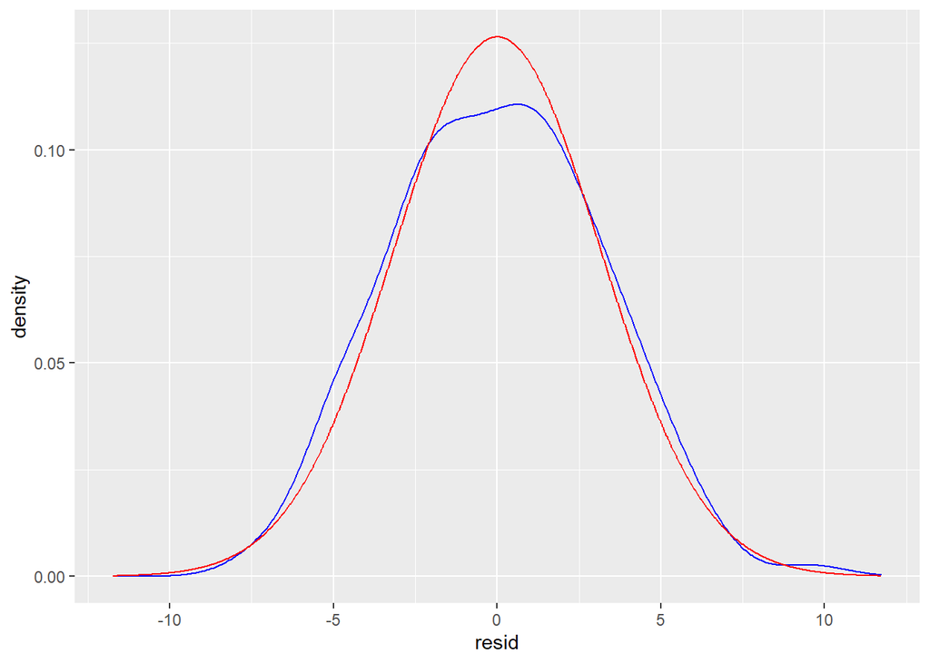

```r
ggplot(mw_winter) +
  geom_density(mapping = aes(x = resid), color = "blue") +
  geom_norm_density(mean(mw_winter$resid), sd(mw_winter$resid), color = "red")
```

Response: A normal distribution would work for this data because the graph displays a “normal” bell shape for the density line of the mean and sd of the residuals. Additionally, the graph isn’t skewed to either side.

### 3

> Make a scatterplot with `year` on the x axis and the residuals on the y axis. Add a horizontal line with a y intercept of zero. Are there strong patterns in the residual plot, or do the residuals resemble random noise? Briefly explain.

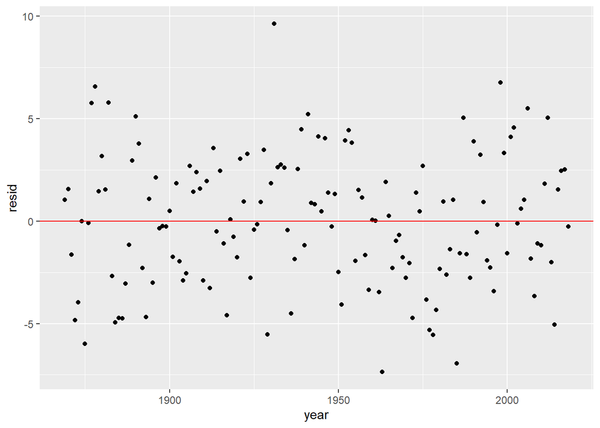

```r
ggplot(mw_winter, mapping = aes(x = year, y = resid)) +
  geom_point() +
  geom_hline(yintercept = 0, color = "red")
```

Response: The only notable take away is that most of the residuals stay within the range of -5 and 5 (this isn’t necessarily a pattern). If the points in a residual plot are randomly dispersed around the horizontal axis, a linear regression model is appropriate for the data; aka a linear regression model fits this data.

### 4

> The code below implements the parametric bootstrap described above. Make density plots of the bootstrap distributions of $a_0$ and $a_1$. Calculate the mean and standard deviation of these bootstrap distributions to three significant digits and compare with the numerical values from the linear model summary. Does the simulation approach agree with the original regression estimates for this data set?

Note: This simulation can be time consuming to re-run every time you knit your R Markdown file. You can set `cache=TRUE` in your chunk header, which will avoid repeating the simulation run (unless a change is made to the chunk). This is already done for you below, but feel free to remove the `cache = TRUE` if you prefer.

```r
n <- nrow(mw_winter)
sigma_resid <- sd(mw_winter$resid)
N <- 10000
a_0 <- numeric(N)
a_1 <- numeric(N)

for ( i in 1:N )
{
  mw_temp <- mw_winter %>%
    mutate(temp = pred + rnorm(n,0,sigma_resid))
  fit_temp <- lm(temp ~ year, data=mw_temp)
  a_0[i] <- coef(fit_temp)[1]
  a_1[i] <- coef(fit_temp)[2]
}

df_coef <- tibble(a_0,a_1)
```

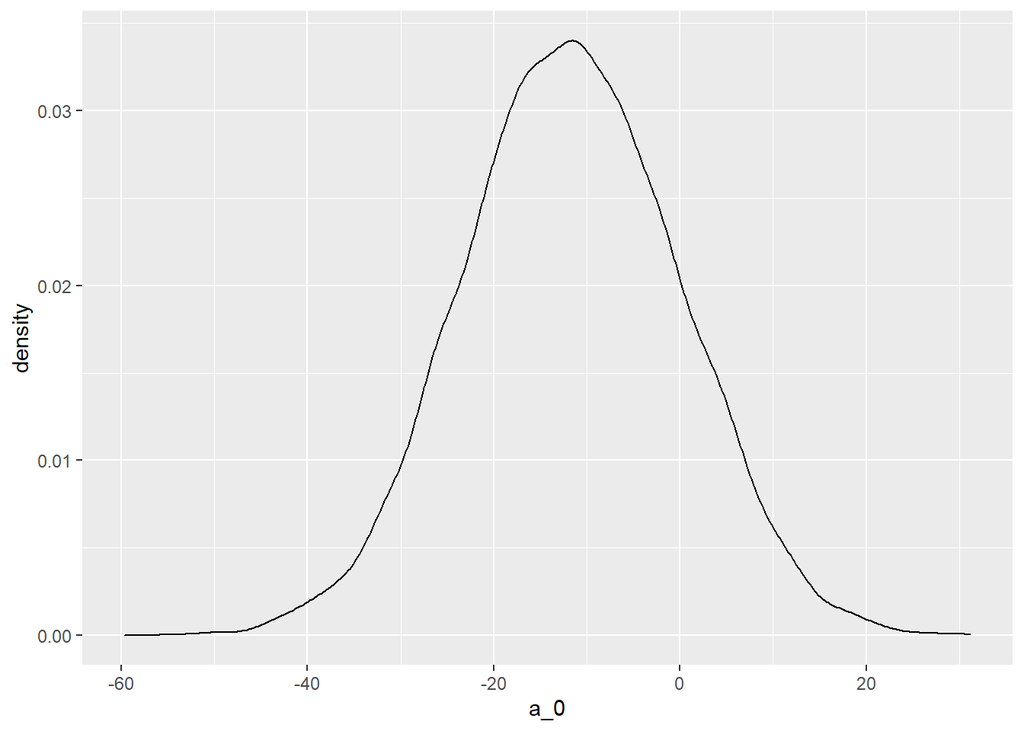

```r
ggplot(df_coef) +
  geom_density(mapping = aes(x = a_0), color = "black")
```

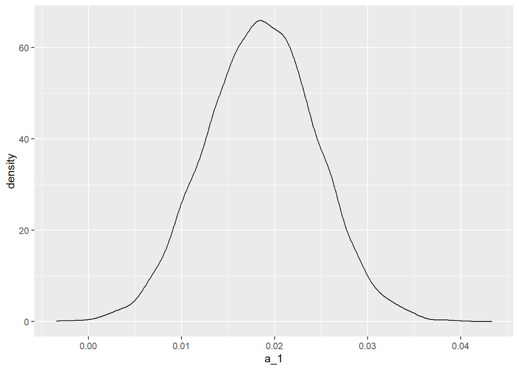

```r
ggplot(df_coef) +
  geom_density(mapping = aes(x = a_1), color = "black")
```

```r
q4 <- df_coef %>%
  summarise(a_0_mean = round(mean(a_0), 3), a_0_sd = round(sd(a_0), 3), a_1_mean = round(mean(a_1), 3), a_1_sd = round(sd(a_1), 3))
q4
```

```
## # A tibble: 1 x 4
##   a_0_mean a_0_sd a_1_mean a_1_sd
##      <dbl>  <dbl>    <dbl>  <dbl>
## 1    -11.7   11.6    0.019  0.006
```

```r
summ <- data.frame(coef(summary(fit)))
summ
```

```
##                 Estimate   Std..Error   t.value   Pr...t..
## (Intercept) -11.98319338 11.604048335 -1.032674 0.30344125
## year          0.01871137  0.005969215  3.134646 0.00207536
```

Response: The simulation approach seems to agree with the original regression estimates for this data set as the values are extremely close to one another.